# Week 9 Text Mining

## Text Mining vs. Data Mining

- Text mining deals with unstructure data (text)
- Conversion from text data to record dataset and then apply all the data mining techniques covered in the course

## Natural Language Processing (NLP)

- Natural language vs. programming language
- Challenges of understanding natural languages (grammar complexity)
- Type of words
- Word play
- Ambiguity
- Voice recognition: accent, tone

## Applications

- Chatbot and dialogue systems
- Virtual assistance
- Topic modeling
- Text classifications
- Speech synthesis
- Voice/speech recognition

## Bag-of-Word (BOW) Model

- Tokenization: break down sentences into words and tokens
- Stop word removal: those words that occur in almost everywhere and don’t significantly differentiate among sentennces, such as articles, pronoun, etc.
- Stemming: replace with the root form of words
- Casing: remove the case difference

## TF-IDF Transformation

- TF (Term Frequency): frequency of the term (t) adjusted for the document (d) length \[ tf(t, d) = \frac{f_t}{f_d} \]
- IDF (Inversed Document Frequency): logarithmically scaled inverse fraction of the collection (\(D\)) of documents (\(d\)) that contain the term (\(t\)). \(N\) is the total number of documents in the corpus (\(N = |D|\)). \[ idf(t, D) = \log\frac{N}{|{d \in D:t \in d}|} \]
- TF-IDF \[ tf-idf(t, d, D) = tf(t, d) * idf(t, D) \]

## Text Mining: Sentiment Analysis

- Sentiment analysis refers to the use of natural language processing, text analysis and computational linguistics to identify and extract subjective information in source materials.
- Simple approach: add the sentiment scores for all the terms used in the documents
- Data science approach: convert text data into Term Document Matrix (TDM) and treat each term as a feature/attribute to build machine learning model

## Load in Necessary Libraries

```r
library(tidytext)
library(stringr)
library(dplyr)
library(tidyr)
library(wordcloud)
library(ggplot2)
```

## Demo Dataset: Yelp Review

```r
reviews <- read.csv("yelp_reviews.csv", stringsAsFactors = FALSE)
str(reviews)
```

```
## 'data.frame':    3000 obs. of  11 variables:
##  $ X           : int  1 2 3 4 5 6 7 8 9 10 ...
##  $ user_id     : chr  "rLtl8ZkDX5vH5nAx9C3q5Q" "0a2KyEL0d3Yb1V6aivbIuQ" "0hT2KtfLiobPvh6cDC8JQg" "uZetl9T0NcROGOyFfughhg" ...
##  $ review_id   : chr  "fWKvX83p0-ka4JS3dc6E5A" "IjZ33sJrzXqU-0X6U8NwyA" "IESLBzqUCLdSzSqm0eCSxQ" "G-WvGaISbqqaMHlNnByodA" ...
##  $ stars       : int  5 5 4 5 5 4 5 4 4 5 ...
##  $ date        : chr  "2011-01-26" "2011-07-27" "2012-06-14" "2010-05-27" ...
##  $ text        : chr  "My wife took me here on my birthday for breakfast and it was excellent.  The weather was perfect which made sit"| __truncated__ "I have no idea why some people give bad reviews about this place. It goes to show you, you can please everyone."| __truncated__ "love the gyro pl…
##  $ type        : chr  "review" "review" "review" "review" ...
##  $ business_id : chr  "9yKzy9PApeiPPOUJEtnvkg" "ZRJwVLyzEJq1VAihDhYiow" "6oRAC4uyJCsJl1X0WZpVSA" "_1QQZuf4zZOyFCvXc0o6Vg" ...
##  $ votes.funny : int  0 0 0 0 0 1 4 0 0 0 ...
##  $ votes.useful: int  5 0 1 2 0 3 7 1 0 1 ...
##  $ votes.cool  : int  2 0 0 1 0 4 7 0 0 0 ...
```

## Tokenization

```r
review_words <- reviews %>%
  select(review_id, business_id, stars, text) %>%
  unnest_tokens(word, text, to_lower = TRUE)
head(review_words, 10)
```

```
##                  review_id            business_id stars      word
## 1   fWKvX83p0-ka4JS3dc6E5A 9yKzy9PApeiPPOUJEtnvkg     5        my
## 1.1 fWKvX83p0-ka4JS3dc6E5A 9yKzy9PApeiPPOUJEtnvkg     5      wife
## 1.2 fWKvX83p0-ka4JS3dc6E5A 9yKzy9PApeiPPOUJEtnvkg     5      took
## 1.3 fWKvX83p0-ka4JS3dc6E5A 9yKzy9PApeiPPOUJEtnvkg     5        me
## 1.4 fWKvX83p0-ka4JS3dc6E5A 9yKzy9PApeiPPOUJEtnvkg     5      here
## 1.5 fWKvX83p0-ka4JS3dc6E5A 9yKzy9PApeiPPOUJEtnvkg     5        on
## 1.6 fWKvX83p0-ka4JS3dc6E5A 9yKzy9PApeiPPOUJEtnvkg     5        my
## 1.7 fWKvX83p0-ka4JS3dc6E5A 9yKzy9PApeiPPOUJEtnvkg     5  birthday
## 1.8 fWKvX83p0-ka4JS3dc6E5A 9yKzy9PApeiPPOUJEtnvkg     5       for
## 1.9 fWKvX83p0-ka4JS3dc6E5A 9yKzy9PApeiPPOUJEtnvkg     5 breakfast
```

## Stemming and Lemmatization

- Goal: reduce inflectional forms and derivationally related forms of a word to a common base form.
- Examples
  - car, cars, car’s, cars’ => car
  - am, are, is => be

```r
library(SnowballC)
review_words$word <- wordStem(review_words$word)
```

## Stop Words: Vocabulary

- A data frame in *tidytext* package with curated stop words (1149)

```r
set.seed(368)
cat(stop_words$word[sample(x = 1:nrow(stop_words), size = 20)], sep = ", ")
```

```
## whose, is, though, anyone, us, actually, if, under, ours, despite, finds, p, followed, hereby, before, once, want, didn't, pointing, available
```

- Source of stop words: 3 lexicons

```r
unique(stop_words$lexicon)
```

```
## [1] "SMART"    "snowball" "onix"
```

## Stop Words: Removal

```r
nrow(review_words)
```

```
## [1] 386390
```

```r
review_words <- review_words %>%
  filter(!word %in% stop_words$word,
         str_detect(word, "^[a-z']+$"))
nrow(review_words)
```

```
## [1] 164797
```

## Frequency and Wordcloud

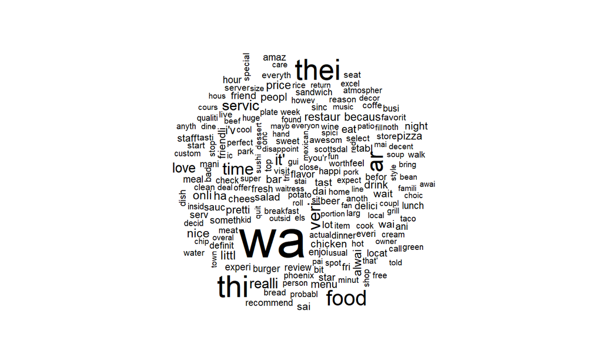

```r
review_words %>%
  count(word) %>%
  with(wordcloud(word, n, max.words = 200))
```

## Sentiment Lexicons

```r
unique(sentiments$lexicon)
```

```
## [1] "nrc"      "bing"     "AFINN"    "loughran"
```

- Data frame contains the lexicon names, sentiment (categories), score (numerical values for the sentiments)

```r
str(sentiments)
```

```
## Classes 'tbl_df', 'tbl' and 'data.frame':    27314 obs. of  4 variables:
##  $ word     : chr  "abacus" "abandon" "abandon" "abandon" ...
##  $ sentiment: chr  "trust" "fear" "negative" "sadness" ...
##  $ lexicon  : chr  "nrc" "nrc" "nrc" "nrc" ...
##  $ score    : int  NA NA NA NA NA NA NA NA NA NA ...
```

## Choose a Lexicon to Score Text Documents

```r
AFINN <- sentiments %>%
  filter(lexicon == 'AFINN') %>%
  select(word, afinn_score = score)

reviews_sentiment <- review_words %>%
  inner_join(AFINN, by = "word") %>%
  group_by(review_id, stars) %>%
  summarise(sentiments = mean(afinn_score))
```

## Correlation of Review Score and the Sentiment

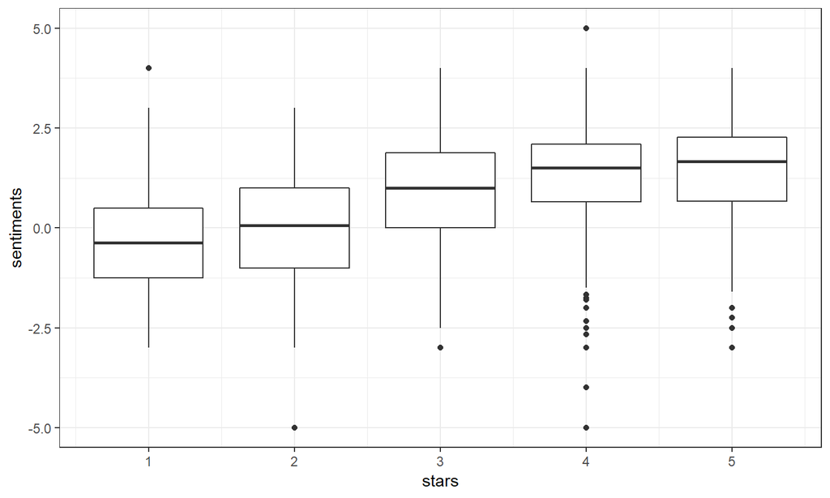

```r
theme_set(theme_bw())
ggplot(reviews_sentiment, aes(stars, sentiments, group = stars)) +
  geom_boxplot()
```

```r
word_summaries <- review_words %>%
  count(review_id, business_id, stars, word) %>%
  group_by(word) %>%
  summarise(businesses = n_distinct(business_id),
            reviews = n(),
            uses = sum(n),
            average_stars = mean(stars)) %>%
  ungroup()

word_summaries_filtered <- word_summaries %>%
  filter(reviews >= 100, businesses >= 5) %>%
  arrange(desc(average_stars))

head(word_summaries_filtered)
```

```
## # A tibble: 6 x 5
##   word      businesses reviews  uses average_stars
##   <chr>          <int>   <int> <int>         <dbl>
## 1 perfect          171     191   211          4.37
## 2 fantast          118     128   141          4.37
## 3 amaz             263     298   345          4.32
## 4 delici           311     354   420          4.30
## 5 awesom           201     214   242          4.28
## 6 recommend        262     276   306          4.25
```

## Visualize the Sentiments of Words in Reviews

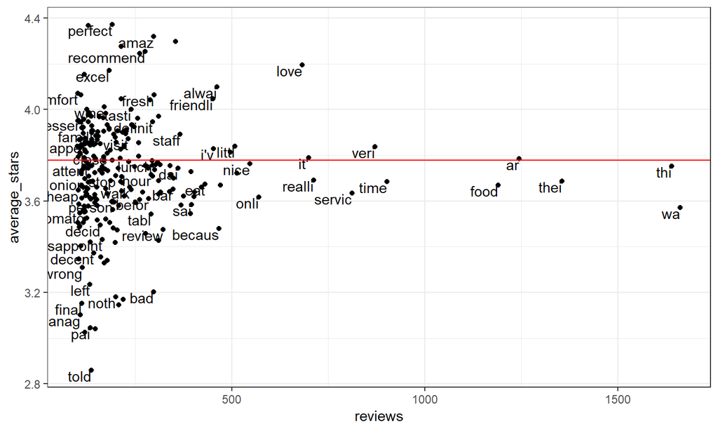

```r
ggplot(word_summaries_filtered, aes(reviews, average_stars)) +
  geom_point() +
  geom_text(aes(label = word), check_overlap = T, vjust = 1, hjust = 1) +
  geom_hline(yintercept = mean(reviews$stars), color = "red")
```

## Construct a Document Term Matrix (DTM)

```r
review_words_dtm <- review_words %>%
  count(review_id, stars, word) %>%
  bind_tf_idf(word, review_id, n) %>%
  select(review_id, stars, word, tf_idf) %>%
  spread(key = word, value = tf_idf)
```